# Chapter 2: Analysis of a survey data — test performance in a statistics course based on student variables

### Introduction to the data

Lets read the data from a local folder and see how many observations and variables we have to work with.

```r
learning2014 <- read.csv("data/learning2014.csv",row.names = "X")
dim(learning2014)
```

```
## [1] 166   7
```

```r
str(learning2014)
```

```
## 'data.frame':    166 obs. of  7 variables:
##  $ gender  : Factor w/ 2 levels "F","M": 1 2 1 2 2 1 2 1 2 1 ...
##  $ age     : int  53 55 49 53 49 38 50 37 37 42 ...
##  $ attitude: num  3.7 3.1 2.5 3.5 3.7 3.8 3.5 2.9 3.8 2.1 ...
##  $ deep    : num  3.58 2.92 3.5 3.5 3.67 ...
##  $ stra    : num  3.38 2.75 3.62 3.12 3.62 ...
##  $ surf    : num  2.58 3.17 2.25 2.25 2.83 ...
##  $ points  : int  25 12 24 10 22 21 21 31 24 26 ...
```

```r
summary(learning2014)
```

```
##  gender       age           attitude          deep            stra
##  F:110   Min.   :17.00   Min.   :1.400   Min.   :1.583   Min.   :1.250
##  M: 56   1st Qu.:21.00   1st Qu.:2.600   1st Qu.:3.333   1st Qu.:2.625
##          Median :22.00   Median :3.200   Median :3.667   Median :3.188
##          Mean   :25.51   Mean   :3.143   Mean   :3.680   Mean   :3.121
##          3rd Qu.:27.00   3rd Qu.:3.700   3rd Qu.:4.083   3rd Qu.:3.625
##          Max.   :55.00   Max.   :5.000   Max.   :4.917   Max.   :5.000
##       surf           points
##  Min.   :1.583   Min.   : 7.00
##  1st Qu.:2.417   1st Qu.:19.00
##  Median :2.833   Median :23.00
##  Mean   :2.787   Mean   :22.72
##  3rd Qu.:3.167   3rd Qu.:27.75
##  Max.   :4.333   Max.   :33.00
```

We have 166 observations and 7 variables from a survey collected from a statistics course. There are two times more females in the data than males. The median age is 22. Attitude, deep, stra, surf are measured in Likert scale. Attitude is a combination of motivation to learn statistics and confidence in their mathematical skills. Deep is a combination of questions related to how people evaluate information and willingness to understand or apply it. Stra measures strategic behavior; how an individual works and plans. Surf on the other hand measures if people are not interested in their studies or concentrate on course requirements rather than on fully understanding the subject, that is, “surface learning” in other words. Points is the maximal overall points that the student got - or “performance”. From the code-blocks above, one can see some vital information about the variables.

### Graphical summarization

Let’s show a graphical overview of the data.

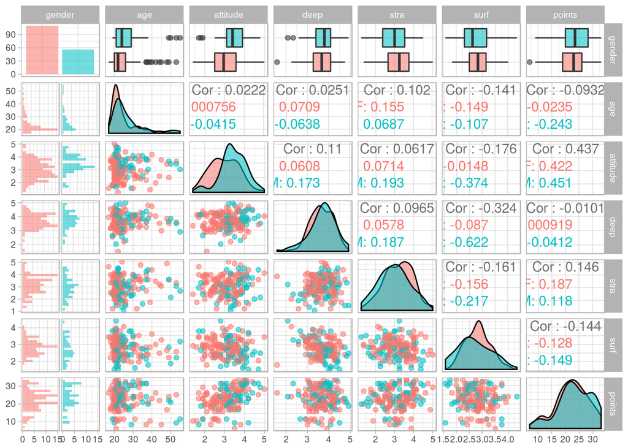

```r
library(ggplot2)
library(GGally)
theme_set(theme_light(base_size=9))
ggpairs(learning2014, mapping = aes(col = gender, alpha = 0.3), lower = list(combo = wrap("facethist", bins = 20)))
```

The above graph summarizes all the relevant graphs of the variables distributions colored based on gender. As one can see, men seem to have a better attitude, less inclined for surface learning and perform slightly better. On the other hand, most females describe themselves as deeper learners and display a higher degree of strategic learning patterns. Another noticiable thing is that men are on average older than their female counterparts. Reader should recognize the different correlations between the variables. Most notable is the high correlation between exam performance and attitude points and the negative correlation of points and surface learning.

### Fitting a regression

```r
model1 <- lm(points ~ deep + surf + gender, data = learning2014)
summary(model1)
```

```
##
## Call:
## lm(formula = points ~ deep + surf + gender, data = learning2014)
##
## Residuals:
##      Min       1Q   Median       3Q      Max
## -14.8988  -3.6363   0.3912   4.2481  10.7905
##
## Coefficients:
##             Estimate Std. Error t value Pr(>|t|)
## (Intercept)  29.8145     4.7353   6.296 2.75e-09 ***
## deep         -0.6964     0.8700  -0.800   0.4246
## surf         -1.7461     0.9159  -1.906   0.0584 .
## genderM       0.9827     0.9680   1.015   0.3115
## ---
## Signif. codes:  0 '***' 0.001 '**' 0.01 '*' 0.05 '.' 0.1 ' ' 1
##
## Residual standard error: 5.857 on 162 degrees of freedom
## Multiple R-squared:  0.03062,    Adjusted R-squared:  0.01267
## F-statistic: 1.706 on 3 and 162 DF,  p-value: 0.1679
```

```r
#remove unsignifficant variables and try a different model

model2 <- lm(points ~ surf + age + stra, data = learning2014 )
summary(model2)
```

```
##
## Call:
## lm(formula = points ~ surf + age + stra, data = learning2014)
##
## Residuals:
##      Min       1Q   Median       3Q      Max
## -15.8229  -3.5885   0.4698   4.1271   9.7896
##
## Coefficients:
##             Estimate Std. Error t value Pr(>|t|)
## (Intercept) 26.28166    3.68767   7.127  3.2e-11 ***
## surf        -1.56432    0.87103  -1.796   0.0744 .
## age         -0.09642    0.05885  -1.638   0.1033
## stra         1.04286    0.59393   1.756   0.0810 .
## ---
## Signif. codes:  0 '***' 0.001 '**' 0.01 '*' 0.05 '.' 0.1 ' ' 1
##
## Residual standard error: 5.792 on 162 degrees of freedom
## Multiple R-squared:  0.05205,    Adjusted R-squared:  0.03449
## F-statistic: 2.965 on 3 and 162 DF,  p-value: 0.03377
```

```r
#remove unsignifficant variables and try a different model

model3 <- lm(points ~ surf + stra + attitude, data = learning2014 )
summary(model3)
```

```
##
## Call:
## lm(formula = points ~ surf + stra + attitude, data = learning2014)
##
## Residuals:
##      Min       1Q   Median       3Q      Max
## -17.1550  -3.4346   0.5156   3.6401  10.8952
##
## Coefficients:
##             Estimate Std. Error t value Pr(>|t|)
## (Intercept)  11.0171     3.6837   2.991  0.00322 **
## surf         -0.5861     0.8014  -0.731  0.46563
## stra          0.8531     0.5416   1.575  0.11716
## attitude      3.3952     0.5741   5.913 1.93e-08 ***
## ---
## Signif. codes:  0 '***' 0.001 '**' 0.01 '*' 0.05 '.' 0.1 ' ' 1
##
## Residual standard error: 5.296 on 162 degrees of freedom
## Multiple R-squared:  0.2074, Adjusted R-squared:  0.1927
## F-statistic: 14.13 on 3 and 162 DF,  p-value: 3.156e-08
```

```r
#remove unsignifficant variables and try a different model

model4 <- lm(points ~ attitude + deep + gender, data = learning2014 )
summary(model4)
```

```
##
## Call:
## lm(formula = points ~ attitude + deep + gender, data = learning2014)
##
## Residuals:
##      Min       1Q   Median       3Q      Max
## -17.0364  -3.2315   0.3561   3.9436  11.0859
##
## Coefficients:
##             Estimate Std. Error t value Pr(>|t|)
## (Intercept)  13.6240     3.1799   4.284 3.13e-05 ***
## attitude      3.6657     0.5984   6.125 6.61e-09 ***
## deep         -0.6172     0.7546  -0.818    0.415
## genderM      -0.4633     0.9170  -0.505    0.614
## ---
## Signif. codes:  0 '***' 0.001 '**' 0.01 '*' 0.05 '.' 0.1 ' ' 1
##
## Residual standard error: 5.337 on 162 degrees of freedom
## Multiple R-squared:  0.1953, Adjusted R-squared:  0.1804
## F-statistic:  13.1 on 3 and 162 DF,  p-value: 1.054e-07
```

```r
#remove unsignifficant variables and try a different model

my_model <- lm(points ~ age + attitude + stra, data= learning2014)
summary(my_model)
```

```
##
## Call:
## lm(formula = points ~ age + attitude + stra, data = learning2014)
##
## Residuals:
##      Min       1Q   Median       3Q      Max
## -18.1149  -3.2003   0.3303   3.4129  10.7599
##
## Coefficients:
##             Estimate Std. Error t value Pr(>|t|)
## (Intercept) 10.89543    2.64834   4.114 6.17e-05 ***
## age         -0.08822    0.05302  -1.664   0.0981 .
## attitude     3.48077    0.56220   6.191 4.72e-09 ***
## stra         1.00371    0.53434   1.878   0.0621 .
## ---
## Signif. codes:  0 '***' 0.001 '**' 0.01 '*' 0.05 '.' 0.1 ' ' 1
##
## Residual standard error: 5.26 on 162 degrees of freedom
## Multiple R-squared:  0.2182, Adjusted R-squared:  0.2037
## F-statistic: 15.07 on 3 and 162 DF,  p-value: 1.07e-08
```

The iterated model is

> points ~ age + attitude + stra

### Interpretation of the linear regression model

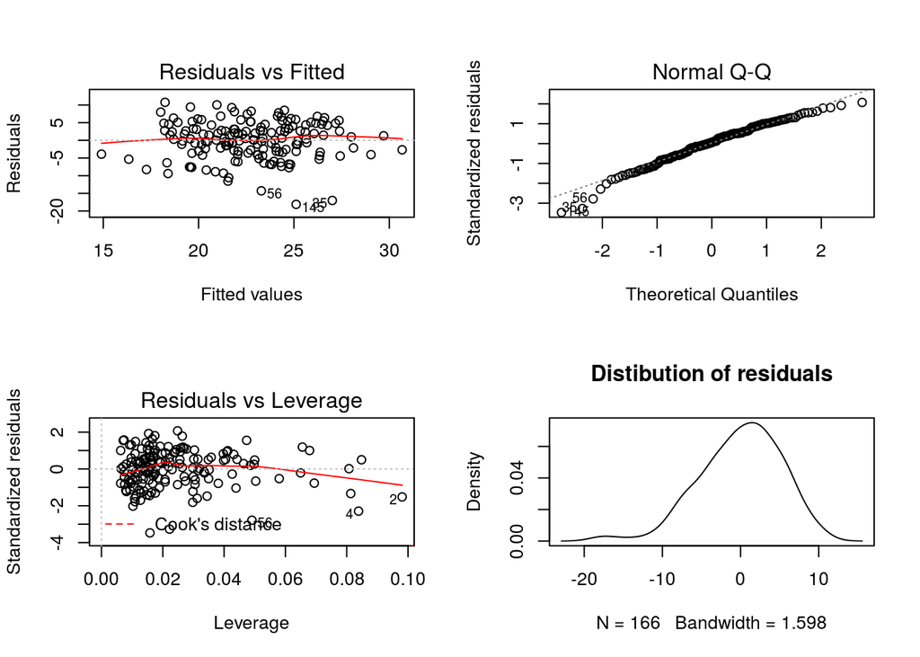

```r
library(ggplot2)
par(mfrow = c(2,2))
plot(my_model, which(c(T,T,F,F,T,F)))


plot(density(my_model$residuals), main="Distibution of residuals")
```

In the plot with fitted values and residuals it is fairly clear that there is no apparent pattern between the two. This suggests that the size of the errors do not depend greatly on the explanatory variables used. We can see from the Q-Q plot that there is a reasonable fit on the line, meaning that the residuals are roughly normally distributed. This is demonstrated on the fourth plot where one can see the distribution of the residuals. On the leverage plot one can see that there are couple of observations which are quite different meaning that these observations might have a big impact on the results, though the numbers are small and we can still be confident in our model.

We can be fairly confident in our model that attitude has the biggest effect on exam performance. Multiple diagnostics of this model confirmed that there are no apparent reason to doubt that the residuals are correlated with the explanatory variables, the residuals are not normally distributed, or our results are based on very high impacting or leveraging outliers.